# Machine Learning Writeup

SB

February 28, 2016

## Summary

This is the writeup on the project assignment for Machine Learning.It is about predicting how well people are performing fitness activities based on data from accelerometers on the belt, forearm, arm, and dumbbell. We will use tree classification, random forest, as well as model based predictions to predict how well 20 participants performed. We will test different sampling methods as well.

```r
library(AppliedPredictiveModeling)
library(caret)
library(rattle)
```

```r
library(rpart.plot)
library(randomForest)
library(gbm)
file_training <- "pml-training.csv"
file_testing <- "pml-testing.csv"
data_training <-read.csv(file_training, na.strings=c("NA",""), header=TRUE)
data_testing <- read.csv(file_testing, na.strings=c("NA",""), header=TRUE)
```

## Explore the data for NA and discard variables that dont have predictive value

```r
col_names <- names(data_training)
print(col_names)
```

```
##   [1] "X"                        "user_name"
##   [3] "raw_timestamp_part_1"     "raw_timestamp_part_2"
##   [5] "cvtd_timestamp"           "new_window"
##   [7] "num_window"               "roll_belt"
##   [9] "pitch_belt"               "yaw_belt"
##  [11] "total_accel_belt"         "kurtosis_roll_belt"
##  [13] "kurtosis_picth_belt"      "kurtosis_yaw_belt"
##  [15] "skewness_roll_belt"       "skewness_roll_belt.1"
##  [17] "skewness_yaw_belt"        "max_roll_belt"
##  [19] "max_picth_belt"           "max_yaw_belt"
##  [21] "min_roll_belt"            "min_pitch_belt"
##  [23] "min_yaw_belt"             "amplitude_roll_belt"
##  [25] "amplitude_pitch_belt"     "amplitude_yaw_belt"
##  [27] "var_total_accel_belt"     "avg_roll_belt"
##  [29] "stddev_roll_belt"         "var_roll_belt"
```

[output cut: 65 more lines]

```r
col_NA <-names(data_training[,colSums(is.na(data_training)) != 0])
data_training_noNA <-data_training[,colSums(is.na(data_training)) == 0]
data_training_noNA <-data_training[,!(names(data_training) %in% col_NA) ]
names_noNA <-names(data_training_noNA)
print(names_noNA)
```

```
##  [1] "X"                    "user_name"            "raw_timestamp_part_1"
##  [4] "raw_timestamp_part_2" "cvtd_timestamp"       "new_window"
##  [7] "num_window"           "roll_belt"            "pitch_belt"
## [10] "yaw_belt"             "total_accel_belt"     "gyros_belt_x"
## [13] "gyros_belt_y"         "gyros_belt_z"         "accel_belt_x"
## [16] "accel_belt_y"         "accel_belt_z"         "magnet_belt_x"
## [19] "magnet_belt_y"        "magnet_belt_z"        "roll_arm"
## [22] "pitch_arm"            "yaw_arm"              "total_accel_arm"
## [25] "gyros_arm_x"          "gyros_arm_y"          "gyros_arm_z"
## [28] "accel_arm_x"          "accel_arm_y"          "accel_arm_z"
## [31] "magnet_arm_x"         "magnet_arm_y"         "magnet_arm_z"
## [34] "roll_dumbbell"        "pitch_dumbbell"       "yaw_dumbbell"
## [37] "total_accel_dumbbell" "gyros_dumbbell_x"     "gyros_dumbbell_y"
## [40] "gyros_dumbbell_z"     "accel_dumbbell_x"     "accel_dumbbell_y"
## [43] "accel_dumbbell_z"     "magnet_dumbbell_x"    "magnet_dumbbell_y"
## [46] "magnet_dumbbell_z"    "roll_forearm"         "pitch_forearm"
## [49] "yaw_forearm"          "total_accel_forearm"  "gyros_forearm_x"
## [52] "gyros_forearm_y"      "gyros_forearm_z"      "accel_forearm_x"
## [55] "accel_forearm_y"      "accel_forearm_z"      "magnet_forearm_x"
## [58] "magnet_forearm_y"     "magnet_forearm_z"     "classe"
```

```r
data_training_prep <-data_training_noNA[,8:length(names_noNA)]
selected_pred <-names(data_training_prep)
print(selected_pred)
```

```
##  [1] "roll_belt"            "pitch_belt"           "yaw_belt"
##  [4] "total_accel_belt"     "gyros_belt_x"         "gyros_belt_y"
##  [7] "gyros_belt_z"         "accel_belt_x"         "accel_belt_y"
## [10] "accel_belt_z"         "magnet_belt_x"        "magnet_belt_y"
## [13] "magnet_belt_z"        "roll_arm"             "pitch_arm"
## [16] "yaw_arm"              "total_accel_arm"      "gyros_arm_x"
## [19] "gyros_arm_y"          "gyros_arm_z"          "accel_arm_x"
## [22] "accel_arm_y"          "accel_arm_z"          "magnet_arm_x"
## [25] "magnet_arm_y"         "magnet_arm_z"         "roll_dumbbell"
## [28] "pitch_dumbbell"       "yaw_dumbbell"         "total_accel_dumbbell"
## [31] "gyros_dumbbell_x"     "gyros_dumbbell_y"     "gyros_dumbbell_z"
## [34] "accel_dumbbell_x"     "accel_dumbbell_y"     "accel_dumbbell_z"
## [37] "magnet_dumbbell_x"    "magnet_dumbbell_y"    "magnet_dumbbell_z"
## [40] "roll_forearm"         "pitch_forearm"        "yaw_forearm"
## [43] "total_accel_forearm"  "gyros_forearm_x"      "gyros_forearm_y"
## [46] "gyros_forearm_z"      "accel_forearm_x"      "accel_forearm_y"
## [49] "accel_forearm_z"      "magnet_forearm_x"     "magnet_forearm_y"
## [52] "magnet_forearm_z"     "classe"
```

## Throw away same columns from test data

```r
data_testing <- data_testing[,!names(data_testing) %in% col_NA]
col_testing <-names(data_testing)
print(col_testing)
```

```
##  [1] "X"                    "user_name"            "raw_timestamp_part_1"
##  [4] "raw_timestamp_part_2" "cvtd_timestamp"       "new_window"
##  [7] "num_window"           "roll_belt"            "pitch_belt"
## [10] "yaw_belt"             "total_accel_belt"     "gyros_belt_x"
## [13] "gyros_belt_y"         "gyros_belt_z"         "accel_belt_x"
## [16] "accel_belt_y"         "accel_belt_z"         "magnet_belt_x"
## [19] "magnet_belt_y"        "magnet_belt_z"        "roll_arm"
## [22] "pitch_arm"            "yaw_arm"              "total_accel_arm"
## [25] "gyros_arm_x"          "gyros_arm_y"          "gyros_arm_z"
## [28] "accel_arm_x"          "accel_arm_y"          "accel_arm_z"
## [31] "magnet_arm_x"         "magnet_arm_y"         "magnet_arm_z"
## [34] "roll_dumbbell"        "pitch_dumbbell"       "yaw_dumbbell"
## [37] "total_accel_dumbbell" "gyros_dumbbell_x"     "gyros_dumbbell_y"
## [40] "gyros_dumbbell_z"     "accel_dumbbell_x"     "accel_dumbbell_y"
## [43] "accel_dumbbell_z"     "magnet_dumbbell_x"    "magnet_dumbbell_y"
## [46] "magnet_dumbbell_z"    "roll_forearm"         "pitch_forearm"
## [49] "yaw_forearm"          "total_accel_forearm"  "gyros_forearm_x"
## [52] "gyros_forearm_y"      "gyros_forearm_z"      "accel_forearm_x"
## [55] "accel_forearm_y"      "accel_forearm_z"      "magnet_forearm_x"
## [58] "magnet_forearm_y"     "magnet_forearm_z"     "problem_id"
```

```r
data_testing_prep <-data_testing[,8:length(col_testing)]
col_testing_prep <-names(data_testing_prep)
print(col_testing_prep)
```

```
##  [1] "roll_belt"            "pitch_belt"           "yaw_belt"
##  [4] "total_accel_belt"     "gyros_belt_x"         "gyros_belt_y"
##  [7] "gyros_belt_z"         "accel_belt_x"         "accel_belt_y"
## [10] "accel_belt_z"         "magnet_belt_x"        "magnet_belt_y"
## [13] "magnet_belt_z"        "roll_arm"             "pitch_arm"
## [16] "yaw_arm"              "total_accel_arm"      "gyros_arm_x"
## [19] "gyros_arm_y"          "gyros_arm_z"          "accel_arm_x"
## [22] "accel_arm_y"          "accel_arm_z"          "magnet_arm_x"
## [25] "magnet_arm_y"         "magnet_arm_z"         "roll_dumbbell"
## [28] "pitch_dumbbell"       "yaw_dumbbell"         "total_accel_dumbbell"
## [31] "gyros_dumbbell_x"     "gyros_dumbbell_y"     "gyros_dumbbell_z"
## [34] "accel_dumbbell_x"     "accel_dumbbell_y"     "accel_dumbbell_z"
## [37] "magnet_dumbbell_x"    "magnet_dumbbell_y"    "magnet_dumbbell_z"
## [40] "roll_forearm"         "pitch_forearm"        "yaw_forearm"
## [43] "total_accel_forearm"  "gyros_forearm_x"      "gyros_forearm_y"
## [46] "gyros_forearm_z"      "accel_forearm_x"      "accel_forearm_y"
## [49] "accel_forearm_z"      "magnet_forearm_x"     "magnet_forearm_y"
## [52] "magnet_forearm_z"     "problem_id"
```

```r
print(dim(data_training_prep))
```

```
## [1] 19622    53
```

```r
print(dim(data_testing_prep))
```

```
## [1] 20 53
```

## Next I started partitioning trainign data to training and test data. I had to take a subdivide the data to reduce computation load

```r
set.seed(1026)
inTrainsub <- createDataPartition(y=data_training_prep$classe, p=0.4, list=FALSE)
data_training_prep_sub1 <- data_training_prep[inTrainsub,]
data_training_prep_sub2 <- data_training_prep[-inTrainsub,]
##Partitioning trainign data into trainign and Testing
inTrain <-createDataPartition(y=data_training_prep_sub1$classe, p=0.6, list=FALSE)
data_training_sub1 <- data_training_prep_sub1[inTrain,]
data_testing_sub1 <- data_training_prep_sub1[-inTrain,]
```

## Since there are more than 2 classes I tried Tree classification.

```r
set.seed(1026)
modFit <- train(data_training_sub1$classe ~ ., data = data_training_sub1 , method="rpart")
print(modFit)
```

```
## CART
##
## 4713 samples
##   52 predictor
##    5 classes: 'A', 'B', 'C', 'D', 'E'
##
## No pre-processing
## Resampling: Bootstrapped (25 reps)
## Summary of sample sizes: 4713, 4713, 4713, 4713, 4713, 4713, ...
## Resampling results across tuning parameters:
##
##   cp          Accuracy   Kappa       Accuracy SD  Kappa SD
##   0.03913430  0.5024714  0.35355083  0.02125904   0.03059881
##   0.05351319  0.4435450  0.25882431  0.05856743   0.09872637
##   0.10999111  0.3297785  0.07091724  0.03858262   0.05931166
##
## Accuracy was used to select the optimal model using  the largest value.
## The final value used for the model was cp = 0.0391343.
```

[figure not shown]

```r
fancyRpartPlot(modFit$finalModel)
```

```r
predictions <-predict(modFit, newdata=data_testing_sub1)
print(confusionMatrix(predictions, data_testing_sub1$classe))
```

```
## Confusion Matrix and Statistics
##
##           Reference
## Prediction   A   B   C   D   E
##          A 800 255 241 234  89
##          B  17 148  13  80  35
##          C  73 204 293 200 184
##          D   0   0   0   0   0
##          E   2   0   0   0 269
##
## Overall Statistics
##
##                Accuracy : 0.4814
##                  95% CI : (0.4637, 0.499)
##     No Information Rate : 0.2843
##     P-Value [Acc > NIR] : < 2.2e-16
##
##                   Kappa : 0.3231
##  Mcnemar's Test P-Value : NA
##
## Statistics by Class:
##
##                      Class: A Class: B Class: C Class: D Class: E
## Sensitivity            0.8969  0.24382   0.5356   0.0000  0.46620
## Specificity            0.6352  0.94269   0.7448   1.0000  0.99922
## Pos Pred Value         0.4941  0.50512   0.3071      NaN  0.99262
## Neg Pred Value         0.9394  0.83861   0.8836   0.8361  0.89253
## Prevalence             0.2843  0.19350   0.1744   0.1639  0.18393
## Detection Rate         0.2550  0.04718   0.0934   0.0000  0.08575
## Detection Prevalence   0.5161  0.09340   0.3041   0.0000  0.08639
## Balanced Accuracy      0.7660  0.59325   0.6402   0.5000  0.73271
```

## We tried to improve accuracy by doing repeated crossvalidation

```r
set.seed(1026)
fitControl <-trainControl(method = "repeatedcv",number = 20,repeats=3)
modFit <- train(data_training_sub1$classe ~ ., data = data_training_sub1 , method="rpart", trControl = fitControl)
print(modFit)
```

```
## CART
##
## 4713 samples
##   52 predictor
##    5 classes: 'A', 'B', 'C', 'D', 'E'
##
## No pre-processing
## Resampling: Cross-Validated (20 fold, repeated 3 times)
## Summary of sample sizes: 4478, 4478, 4477, 4476, 4477, 4477, ...
## Resampling results across tuning parameters:
##
##   cp          Accuracy   Kappa       Accuracy SD  Kappa SD
##   0.03913430  0.4886569  0.33137602  0.03165996   0.04127700
##   0.05351319  0.4182875  0.21758794  0.05648128   0.09751646
##   0.10999111  0.3149837  0.04697296  0.03420252   0.05179317
##
## Accuracy was used to select the optimal model using  the largest value.
## The final value used for the model was cp = 0.0391343.
```

[figure not shown]

```r
fancyRpartPlot(modFit$finalModel)
```

```r
predictions <-predict(modFit, newdata=data_testing_sub1)
print(confusionMatrix(predictions, data_testing_sub1$classe))
```

```
## Confusion Matrix and Statistics
##
##           Reference
## Prediction   A   B   C   D   E
##          A 800 255 241 234  89
##          B  17 148  13  80  35
##          C  73 204 293 200 184
##          D   0   0   0   0   0
##          E   2   0   0   0 269
##
## Overall Statistics
##
##                Accuracy : 0.4814
##                  95% CI : (0.4637, 0.499)
##     No Information Rate : 0.2843
##     P-Value [Acc > NIR] : < 2.2e-16
##
##                   Kappa : 0.3231
##  Mcnemar's Test P-Value : NA
##
## Statistics by Class:
##
##                      Class: A Class: B Class: C Class: D Class: E
## Sensitivity            0.8969  0.24382   0.5356   0.0000  0.46620
## Specificity            0.6352  0.94269   0.7448   1.0000  0.99922
## Pos Pred Value         0.4941  0.50512   0.3071      NaN  0.99262
## Neg Pred Value         0.9394  0.83861   0.8836   0.8361  0.89253
## Prevalence             0.2843  0.19350   0.1744   0.1639  0.18393
## Detection Rate         0.2550  0.04718   0.0934   0.0000  0.08575
## Detection Prevalence   0.5161  0.09340   0.3041   0.0000  0.08639
## Balanced Accuracy      0.7660  0.59325   0.6402   0.5000  0.73271
```

## Since Random Forest is supposed to have high accuracy, I tried it next

## with repeated crossvalidation to avoid overfitting. For the markup I couldnt use repeated

## cross validation because my Rsession crashed due to low memory

```r
set.seed(1026)
modFit <-train(data_training_sub1$classe ~ ., method="rf",trControl = trainControl(method = "cv", number = 4), data = data_training_sub1)
print(modFit)
```

```
## Random Forest
##
## 4713 samples
##   52 predictor
##    5 classes: 'A', 'B', 'C', 'D', 'E'
##
## No pre-processing
## Resampling: Cross-Validated (4 fold)
## Summary of sample sizes: 3535, 3534, 3535, 3535
## Resampling results across tuning parameters:
##
##   mtry  Accuracy   Kappa      Accuracy SD  Kappa SD
##    2    0.9637171  0.9540760  0.008096066  0.010245358
##   27    0.9690219  0.9607985  0.006295000  0.007975108
##   52    0.9603224  0.9497861  0.008005618  0.010131686
##
## Accuracy was used to select the optimal model using  the largest value.
## The final value used for the model was mtry = 27.
```

```r
predictions <-predict(modFit, newdata=data_testing_sub1)
print(confusionMatrix(predictions, data_testing_sub1$classe))
```

```
## Confusion Matrix and Statistics
##
##           Reference
## Prediction   A   B   C   D   E
##          A 887  15   0   0   0
##          B   0 581  19   0   1
##          C   4   8 525  15   2
##          D   1   3   3 495   6
##          E   0   0   0   4 568
##
## Overall Statistics
##
##                Accuracy : 0.9742
##                  95% CI : (0.968, 0.9794)
##     No Information Rate : 0.2843
##     P-Value [Acc > NIR] : < 2.2e-16
##
##                   Kappa : 0.9673
##  Mcnemar's Test P-Value : NA
##
## Statistics by Class:
##
##                      Class: A Class: B Class: C Class: D Class: E
## Sensitivity            0.9944   0.9572   0.9598   0.9630   0.9844
## Specificity            0.9933   0.9921   0.9888   0.9950   0.9984
## Pos Pred Value         0.9834   0.9667   0.9477   0.9744   0.9930
## Neg Pred Value         0.9978   0.9897   0.9915   0.9928   0.9965
## Prevalence             0.2843   0.1935   0.1744   0.1639   0.1839
## Detection Rate         0.2828   0.1852   0.1674   0.1578   0.1811
## Detection Prevalence   0.2875   0.1916   0.1766   0.1619   0.1823
## Balanced Accuracy      0.9939   0.9746   0.9743   0.9790   0.9914
```

## I tried to use prox argument to get additional information and look at individual trees, but my computer ran out of memory

## With 4 times repeated 10 folds crossvalidation I got 99% accuracy. But I had to omit it from the markdown since teh computation was taking a long time.Since random forest was giving a fairly very high accuracy, so I used this modelfit to predict the performance categories in the test data.

```r
print(predict(modFit, newdata=data_testing_prep))
```

```
##  [1] B A A A A E D B A A B C B A E E A B B B
## Levels: A B C D E
```

## I wanted to test different K folds and leave one out for crossvalidation, but was struggling with

## computer memory at this point. I also tried gradient boosting and got an accuracy of .966-leaving this from the markdown

## once again because of computation speed and memory issues.

## I also tried model based predictions

```r
set.seed(1026)
modFit <-train(data_training_sub1$classe ~ ., method="lda",trControl = trainControl(method="cv",number=4), data = data_training_sub1)
print(modFit)
```

```
## Linear Discriminant Analysis
##
## 4713 samples
##   52 predictor
##    5 classes: 'A', 'B', 'C', 'D', 'E'
##
## No pre-processing
## Resampling: Cross-Validated (4 fold)
## Summary of sample sizes: 3535, 3534, 3535, 3535
## Resampling results
##
##   Accuracy   Kappa      Accuracy SD  Kappa SD
##   0.7095271  0.6327837  0.01805971   0.02268377
##
##
```

```r
predictions <-predict(modFit, newdata=data_testing_sub1)
print(confusionMatrix(predictions, data_testing_sub1$classe))
```

```
## Confusion Matrix and Statistics
##
##           Reference
## Prediction   A   B   C   D   E
##          A 704  94  43  34  24
##          B  25 387  60  28 101
##          C  93  60 366  70  57
##          D  66  22  58 359  51
##          E   4  44  20  23 344
##
## Overall Statistics
##
##                Accuracy : 0.6886
##                  95% CI : (0.672, 0.7047)
##     No Information Rate : 0.2843
##     P-Value [Acc > NIR] : < 2.2e-16
##
##                   Kappa : 0.6063
##  Mcnemar's Test P-Value : < 2.2e-16
##
## Statistics by Class:
##
##                      Class: A Class: B Class: C Class: D Class: E
## Sensitivity            0.7892   0.6376   0.6691   0.6984   0.5962
## Specificity            0.9131   0.9154   0.8919   0.9249   0.9645
## Pos Pred Value         0.7831   0.6439   0.5666   0.6457   0.7908
## Neg Pred Value         0.9160   0.9132   0.9273   0.9399   0.9138
## Prevalence             0.2843   0.1935   0.1744   0.1639   0.1839
## Detection Rate         0.2244   0.1234   0.1167   0.1144   0.1097
## Detection Prevalence   0.2866   0.1916   0.2059   0.1772   0.1387
## Balanced Accuracy      0.8512   0.7765   0.7805   0.8117   0.7803
```

## I also plotted the 2 variables pitch_forearm and roll_belt against each other, colored

## by Class but as can be seen from the plot there is no easy classifier

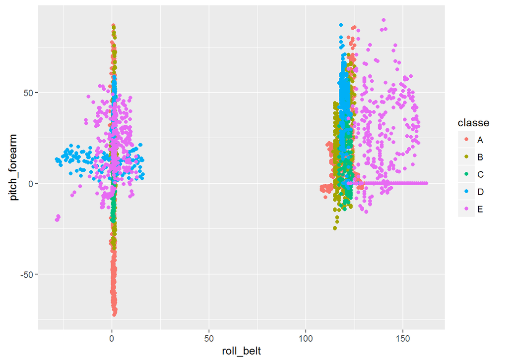

```r
qplot(roll_belt,pitch_forearm,color=classe,data=data_training_sub1)
```

##From this plot it is not surprising that linear model based predictions has lower accuracy than random forest ##for this dataset ##At this point I called it a day